# Porównanie metod wyboru atrybutów dla danych k-merowych - follow-up

17/03/2021

## Przypomnienie

## Cel

- każda sekwencja reprezentowana jako wiersz macierzy k-merów
- Dla każdego \(k\)-meru: \(k \in \{1, 2, 3, 4\};~d \in \{0,\dots,6\}\)

Motywacja i cel pracy

- redukcja wymiarowości przestrzeni \(k\)-merowej
- filtrowanie \(k\)-merów

## Dane

Losowo generowane sekwencje:

- długości 10
- alfabet 6-elementowy
- Prawdopodobieństwo elementów: `amylogram encoding`

Losowo generowane motywy:

- postać \(k\)-meru: \(k \in \{1, 2, 3, 4\};~d \in \{0,\dots,6\}\)
- prawdopodobieństwo elementów: `amylogram encoding`

## Metody

Filtry rankingowe

- testy: QuiPT, \(\chi^2\)
- SU, IG, GR
- Information-Based: NJMIM, MRMR, JMIM, JMI, DISR

Filtry nierankingowe

- FCBF
- QuiPT
- \(\chi^2\)

## Analiza metod filtrowania k-merów

Schemat ewaluacji:

- rankingi: siatka \(k\)-merów: \(1-128, 2^i,8 \leq i \leq 12\)
- metryki: AUC, dokładność i inne
- 5-fold CV

Modele:

- LASSO
- Random Forest
- Naive Bayes
- k-NN

## Eksperyment I

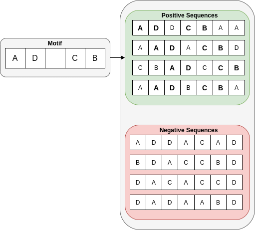

## Eksperyment II

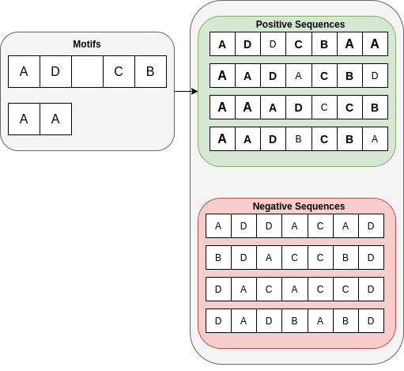

## Eksperyment III

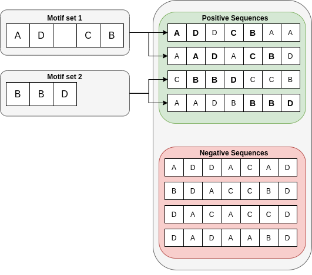

## Eksperyment IV

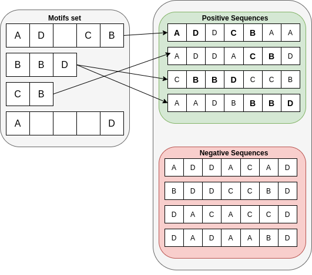

## Exp I - Baseline (1 motyw, 300 sekwencji) - wyniki

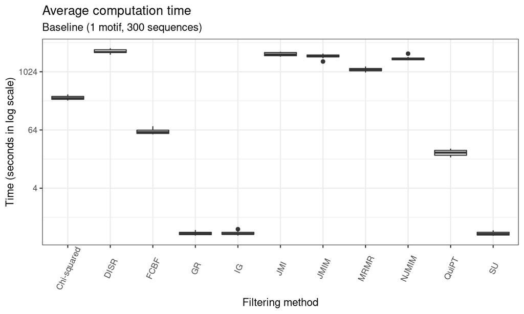

## Wyniki cd.

|  | n-kmers selected | Accuracy | Sensitivity | AUC |
| --- | --- | --- | --- | --- |
| QuiPT (nr) | 392.5 +- 47.921 | 0.946 +- 0.026 | 0.983 +- 0.012 | 0.97 +- 0.021 |
| Chi-squared (nr) | 912.2 +- 67.411 | 0.948 +- 0.018 | 0.993 +- 0.007 | 0.98 +- 0.012 |
| FCBF | 5.6 +- 0.733 | 0.991 +- 0.004 | 1 +- 0 | 0.996 +- 0.003 |

## Wyniki cd.

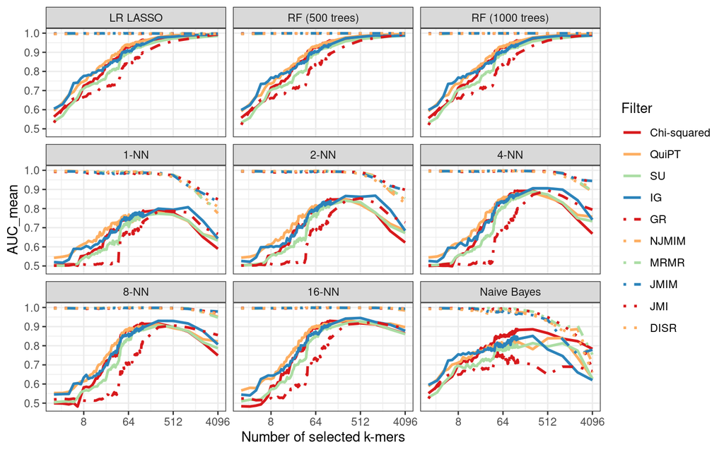

## Pytania

## Pytanie I

Jak prezentować wyniki?

- porównanie metod rankingowych z nierankingowymi
- wygląd (dobór kolorów, typów linii itd.)
- oddzielne porównanie najlepszych filtrów

## Pytanie 2

- Czy eksperymenty III i IV są dobrze zaprojektowane?
- Dobór wielkości zbioru motywów
- Parametry łączenia zbiorów danych

## Pytanie 3 - Analiza filtrowanych k-merów

Czy porównanie podzbiorów \(k\)-merów jest sensowne?

Pomysły:

- diagramy Venna
- wordclouds
- wyjaśnienie poprzez “dobry” klasyfikator